# Bibliometrics

#### **Journal Citation Reports**

http://ipscience-help.thomsonreuters.com/incitesLiveJCR/welcomeToTheNewJCR.html

#### **CiteScore metrics from Scopus**

https://journalmetrics.scopus.com/

#### **Semantic Scholar**

https://www.semanticscholar.org/

#### **colwiz**

https://www.colwiz.com/

- **Publish or Perish**

https://www.harzing.com/resources/publish-or-perish

- **Scientometrics**

http://link.springer.com/journal/11192

- **OECD work on scientometrics and bibliometrics**

http://www.oecd.org/sti/inno/scientometrics.htm

- **Türkiye Bilimsel Yayın Performans Raporları**

http://cabim.ulakbim.gov.tr/bibliyometrik-analiz/turkiye-bilimsel-yayin-performans-raporlari/

- **Ranking of scientists in Turkish Institutions according to their Google Scholar Citations public profiles**

http://webometrics.info/en/node/72

https://web.archive.org/web/20170718030609/http://webometrics.info/en/node/72

- **H-endeksi değerlerine göre 100 Türk bilim insanı**

http://www.turkishtimedergi.com/genel/h-endeksi-degerlerine-gore-100-turk-bilim-insani/

- **Classic Papers: Articles That Have Stood The Test of Time**

https://scholar.googleblog.com/2017/06/classic-papers-articles-that-have-stood.html

- Some things you need to know about Google Scholar

http://ideophone.org/some-things-you-need-to-know-about-google-scholar/

- Manipulating Google Scholar Citations and Google Scholar Metrics: simple, easy and tempting

https://arxiv.org/abs/1212.0638

- Gaming Google Scholar Citations, Made Simple and Easy

https://scholarlykitchen.sspnet.org/2012/12/12/gaming-google-scholar-citations-made-simple-and-easy/

- SJR Scimago Journal & Country Rank

Pathology articles from Turkey: 18th in number, 34th H-index, 92nd citation/document among other countries twitter.com/scimago

http://www.scimagojr.com/countryrank.php?category=2734

- Do We Need A Self-Citation Index?

https://scholarlykitchen.sspnet.org/2017/09/13/need-self-citation-index/

- SCI-EXPANDED, SSCI ve AHCI KAPSAMINDAKİ TÜRK DERGİLERİ

http://uvt.ulakbim.gov.tr/tip/sempozyum4/page86-92.pdf

- TÜRK DERGİLERİNİN WEB OF SCIENCE’TEKİ YERİ, İMPAKT FAKTÖR (ETKİ FAKTÖRÜ) VE H İNDEKS

http://uvt.ulakbim.gov.tr/tip/sempozyum11/Sayfa-53-74.pdf

- ISI Web of Science (WoS)’da İndekslenen Türkiye Adresli Bilimsel Dergiler

http://ulakbim.tubitak.gov.tr/tr/hizmetlerimiz/isi-web-science-wosda-indekslenen-turkiye-adresli-bilimsel-dergiler

- Thomson Reuters Web Of Science Atıf Veri Tabanlarında (SCI, SSCI, AHCI) İndekslenmekte Olan Türkiye Adresli Bilimsel Dergiler

http://ulakbim.tubitak.gov.tr/sites/images/Ulakbim/wos_turkce_dergiler_aralik_2014.pdf

- Webometrics

http://webometrics.info/en/Europe/Turkey

- CWTS Journal Indicators

http://www.journalindicators.com/

http://www.journalindicators.com/indicators

http://www.journalindicators.com/methodology

http://www.sciencedirect.com/science/article/pii/S1751157712001010?via%3Dihub

- University Rank

http://www.umultirank.org/#!/home

- The Leiden Manifesto for Research Metrics

http://www.leidenmanifesto.org/

https://vimeo.com/133683418

- Diana Hicks, Paul Wouters, Ludo Waltman, Sarah de Rijke, Ismael Rafols (2015) The Leiden Manifesto for research metrics: use these 10 principles to guide research evaluation. Nature, April 23, 520:429-431, doi:10.1038/520429a.

https://www.nature.com/news/bibliometrics-the-leiden-manifesto-for-research-metrics-1.17351

- Report compares UK’s research performance with key nations

https://www.elsevier.com/connect/report-compares-uks-research-performance-with-key-nations?sf171414552=1

- It’s Gonna Get a Lot Easier to Break Science Journal Paywalls

https://www.wired.com/story/its-gonna-get-a-lot-easier-to-break-science-journal-paywalls/?mbid=social_twitter_onsiteshare

- The science that’s never been cited: Nature investigates how many papers really end up without a single citation.

https://www.nature.com/articles/d41586-017-08404-0?utm_source=FBK_NatureNews&sf176431210=1

- **The SCImago Journal & Country Rank**

https://www.scimagojr.com/journalrank.php?category=2734&area=2700

- **Citation Performance Indicators — A Very Short Introduction**

https://scholarlykitchen.sspnet.org/2017/05/15/citation-performance-indicators-short-introduction/

- **Journal Citation Reports**

http://ipscience-help.thomsonreuters.com/incitesLiveJCR/welcomeToTheNewJCR.html

- **CiteScore metrics from Scopus**

https://journalmetrics.scopus.com/

- **Semantic Scholar**

https://www.semanticscholar.org/

- **Google Scholar**
- **Research Gate**
- **EndNote**
- **colwiz**

https://www.colwiz.com/

- **Publish or Perish**

https://www.harzing.com/resources/publish-or-perish

- **Scientometrics**

http://link.springer.com/journal/11192

- **OECD work on scientometrics and bibliometrics**

http://www.oecd.org/sti/inno/scientometrics.htm

- **Türkiye Bilimsel Yayın Performans Raporları**

http://cabim.ulakbim.gov.tr/bibliyometrik-analiz/turkiye-bilimsel-yayin-performans-raporlari/

- **Ranking of scientists in Turkish Institutions according to their Google Scholar Citations public profiles**

http://webometrics.info/en/node/72

https://web.archive.org/web/20170718030609/http://webometrics.info/en/node/72

- **H-endeksi değerlerine göre 100 Türk bilim insanı**

http://www.turkishtimedergi.com/genel/h-endeksi-degerlerine-gore-100-turk-bilim-insani/

- **Classic Papers: Articles That Have Stood The Test of Time**

https://scholar.googleblog.com/2017/06/classic-papers-articles-that-have-stood.html

- Some things you need to know about Google Scholar

http://ideophone.org/some-things-you-need-to-know-about-google-scholar/

- Manipulating Google Scholar Citations and Google Scholar Metrics: simple, easy and tempting

https://arxiv.org/abs/1212.0638

- Gaming Google Scholar Citations, Made Simple and Easy

https://scholarlykitchen.sspnet.org/2012/12/12/gaming-google-scholar-citations-made-simple-and-easy/

- SJR Scimago Journal & Country Rank

Pathology articles from Turkey: 18th in number, 34th H-index, 92nd citation/document among other countries twitter.com/scimago

http://www.scimagojr.com/countryrank.php?category=2734

- Do We Need A Self-Citation Index?

https://scholarlykitchen.sspnet.org/2017/09/13/need-self-citation-index/

- SCI-EXPANDED, SSCI ve AHCI KAPSAMINDAKİ TÜRK DERGİLERİ

http://uvt.ulakbim.gov.tr/tip/sempozyum4/page86-92.pdf

- TÜRK DERGİLERİNİN WEB OF SCIENCE’TEKİ YERİ, İMPAKT FAKTÖR (ETKİ FAKTÖRÜ) VE H İNDEKS

http://uvt.ulakbim.gov.tr/tip/sempozyum11/Sayfa-53-74.pdf

- ISI Web of Science (WoS)’da İndekslenen Türkiye Adresli Bilimsel Dergiler

http://ulakbim.tubitak.gov.tr/tr/hizmetlerimiz/isi-web-science-wosda-indekslenen-turkiye-adresli-bilimsel-dergiler

- Thomson Reuters Web Of Science Atıf Veri Tabanlarında (SCI, SSCI, AHCI) İndekslenmekte Olan Türkiye Adresli Bilimsel Dergiler

http://ulakbim.tubitak.gov.tr/sites/images/Ulakbim/wos_turkce_dergiler_aralik_2014.pdf

- Webometrics

http://webometrics.info/en/Europe/Turkey

- CWTS Journal Indicators

http://www.journalindicators.com/

http://www.journalindicators.com/indicators

http://www.journalindicators.com/methodology

http://www.sciencedirect.com/science/article/pii/S1751157712001010?via%3Dihub

- University Rank

http://www.umultirank.org/#!/home

- The Leiden Manifesto for Research Metrics

http://www.leidenmanifesto.org/

https://vimeo.com/133683418

- Diana Hicks, Paul Wouters, Ludo Waltman, Sarah de Rijke, Ismael Rafols (2015) The Leiden Manifesto for research metrics: use these 10 principles to guide research evaluation. Nature, April 23, 520:429-431, doi:10.1038/520429a.

https://www.nature.com/news/bibliometrics-the-leiden-manifesto-for-research-metrics-1.17351

- Report compares UK’s research performance with key nations

https://www.elsevier.com/connect/report-compares-uks-research-performance-with-key-nations?sf171414552=1

- It’s Gonna Get a Lot Easier to Break Science Journal Paywalls

https://www.wired.com/story/its-gonna-get-a-lot-easier-to-break-science-journal-paywalls/?mbid=social_twitter_onsiteshare

- The science that’s never been cited: Nature investigates how many papers really end up without a single citation.

https://www.nature.com/articles/d41586-017-08404-0?utm_source=FBK_NatureNews&sf176431210=1

- Scholar Profili eksik olanlara öneriler

http://www.webometrics.info/en/node/179

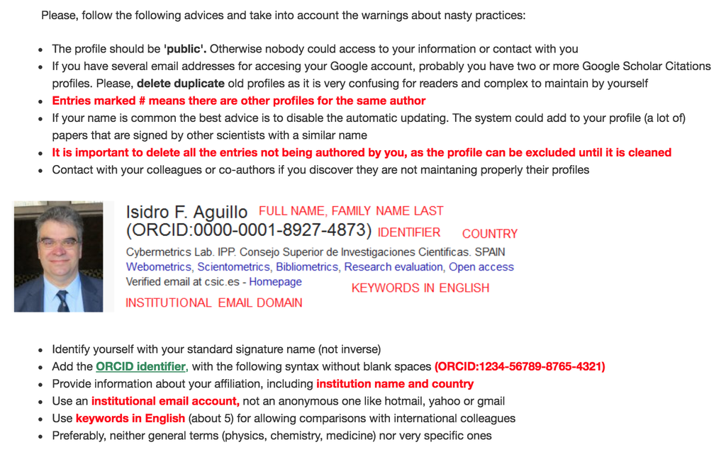

- Webometric Analyst 2.0

http://lexiurl.wlv.ac.uk/

- Medical Journals: A Sluggish Form of Twitter?

https://www.medpagetoday.com/blogs/revolutionandrevelation/79274